# Estudio de reflectividad en campos de agave: corrección de la banda 2

QUETZALCOATL SINUE & V. Shalisko

3 de mayo de 2017

#### Cargar bibliotecas necesarias

```r
library(foreign)
library(mgcv)
```

#### Nota: los fragmentos del código 1, 2 y 3 fueron copiados desde MODELO_correccion_estudio_de_datos.Rmd

#### Cargar las tablas con datos de muestreo de imagenes 2013, 2014, 2015

```r
# fragmento del codigo 1
mydata2013<-read.dbf("Clip_PunRas_Buffer_45m_inters_2013.dbf")
mydata2013[mydata2013["FECH_SIEM"] == 0,"FECH_SIEM"] <- NA # sustituir fecha de siembra 0 por NA

mydata2014<-read.dbf("Clip_punRas_Buffer_45m_intersec_2014.dbf")
mydata2014[mydata2014["FECH_SIEM"] == 0,"FECH_SIEM"] <- NA # sustituir fecha de siembra 0 por NA

mydata2015<-read.dbf("Clip_punRas_Buffer_45m_intersec_2015.dbf")
mydata2015[mydata2015["FECH_SIEM"] == 0,"FECH_SIEM"] <- NA # sustituir fecha de siembra 0 por NA

# Prueba opcional: para seleccionar solo datos con agaves sin vegetación
# mydata2013 <- subset(mydata2013, PORC_VEG == 0)
# mydata2014 <- subset(mydata2014, PORC_VEG == 0)
# mydata2015 <- subset(mydata2015, PORC_VEG == 0)
```

## Normalización de mediana de reflectividad en bandas para hacer compatibles datos de muestreo de las tres imagenes

```r
# fragmento del código 2
# normalización de mediana consiste en que cada una de las muestras se ajusta sobre la mediana

mydata2013_b2n <- mydata2013[,"BANDA_2"] - median(mydata2013[,"BANDA_2"])
mydata2014_b2n <- mydata2014[,"banda_2"] - median(mydata2014[,"banda_2"])
mydata2015_b2n <- mydata2015[,"banda2"] - median(mydata2015[,"banda2"])

mydata2013_b3n <- mydata2013[,"BANDA_3"] - median(mydata2013[,"BANDA_3"])
mydata2014_b3n <- mydata2014[,"banda_3"] - median(mydata2014[,"banda_3"])
mydata2015_b3n <- mydata2015[,"banda3"] - median(mydata2015[,"banda3"])

mydata2013_b4n <- mydata2013[,"BANDA_4"] - median(mydata2013[,"BANDA_4"])
mydata2014_b4n <- mydata2014[,"banda_4"] - median(mydata2014[,"banda_4"])
mydata2015_b4n <- mydata2015[,"banda4"] - median(mydata2015[,"banda4"])

mydata2013_b5n <- mydata2013[,"BANDA_5"] - median(mydata2013[,"BANDA_5"])
mydata2014_b5n <- mydata2014[,"banda_5"] - median(mydata2014[,"banda_5"])
mydata2015_b5n <- mydata2015[,"banda5"] - median(mydata2015[,"banda5"])

mydata2013_b6n <- mydata2013[,"BANDA_6"] - median(mydata2013[,"BANDA_6"])
mydata2014_b6n <- mydata2014[,"banda_6"] - median(mydata2014[,"banda_6"])
mydata2015_b6n <- mydata2015[,"banda6"] - median(mydata2015[,"banda6"])

mydata2013_b7n <- mydata2013[,"BANDA_7"] - median(mydata2013[,"BANDA_7"])
mydata2014_b7n <- mydata2014[,"banda_7"] - median(mydata2014[,"banda_7"])
mydata2015_b7n <- mydata2015[,"banda7"] - median(mydata2015[,"banda7"])
```

#### Integración de las tablas que corresponden a imagenes en tres fechas en una sola tabla para el analisis posterior

```r
# fragmento del código 3
# porentaje de vegetación es columna numerica y no requiere conversión
mydataFULL_PORC_VEG <- c(mydata2013[,"PORC_VEG"],mydata2014[,"PORC_VEG"],mydata2015[,"PORC_VEG"])
# rango es un factor y requiere transformación a cadenas de simbolos
mydataFULL_RANGO <- c(as.character(mydata2013[,"Rango"]),
                      as.character(mydata2014[,"Rango"]),
                      as.character(mydata2015[,"Rango"]))
# fecha de siembra es un factor y requiere transformación a cadenas de simbolos
mydataFULL_FECH_SIEM <- c(as.character(mydata2013[,"FECH_SIEM"]),
                          as.character(mydata2014[,"FECH_SIEM"]),
                          as.character(mydata2015[,"FECH_SIEM"]))

# bandas normalizadas con mediana son numéricas y non requieren conversión de formato
mydataFULL_b2n <- c(mydata2013_b2n,mydata2014_b2n,mydata2015_b2n)
mydataFULL_b3n <- c(mydata2013_b3n,mydata2014_b3n,mydata2015_b3n)
mydataFULL_b4n <- c(mydata2013_b4n,mydata2014_b4n,mydata2015_b4n)
mydataFULL_b5n <- c(mydata2013_b5n,mydata2014_b5n,mydata2015_b5n)
mydataFULL_b6n <- c(mydata2013_b6n,mydata2014_b6n,mydata2015_b6n)
mydataFULL_b7n <- c(mydata2013_b7n,mydata2014_b7n,mydata2015_b7n)

mydataFULL <- data.frame(
                        porc_veg=mydataFULL_PORC_VEG,
                        rango=mydataFULL_RANGO,
                        fech_siem=mydataFULL_FECH_SIEM,
                        porc_veg_f=as.factor(mydataFULL_PORC_VEG),
                        b2n=mydataFULL_b2n,
                        b3n=mydataFULL_b3n,
                        b4n=mydataFULL_b4n,
                        b5n=mydataFULL_b5n,
                        b6n=mydataFULL_b6n,
                        b7n=mydataFULL_b7n)

# convertir columnas de rango y fecha de siembra a factores
mydataFULL[,"rango_f"] <- as.factor(mydataFULL[,"rango"])
mydataFULL[,"rango_f"] <- factor(mydataFULL[,"rango"], levels = c("0-3","3-12","12-30","30-45"))
mydataFULL[,"fech_siem_f"] <- as.factor(mydataFULL[,"fech_siem"])
mydataFULL[,"fech_siem_f"] <- factor(mydataFULL[,"fech_siem"],
    levels = c("2005","2006","2007","2008","2009","2010","2011","2012","2013","2014","2015","2016"))
```

# TRATAMIENTO DE BANDA 2

#### A partir de este punto solo se trabaja con los datos de la banda 2 en la tabla integrada

## Primera corección

### Inferirencia de la respuesta a rangos de pendiente para BANDA 2 (modelo *myfit_b2n*)

```r
# convertir columna rango en una columna numérica (enteros) ordenada en secuencia de rangos deseada
mydataFULL[,"rango_n"] <- as.numeric(factor(mydataFULL[,"rango"], levels= c("0-3","3-12","12-30","30-45")))

# construir un modelo de respuesta de reflectividad a rango de pendiente por medio de GAM
myfit_b2n <- gam(b2n ~ s(rango_n, k=3, fx = TRUE, bs="cr"), data=mydataFULL)

# resumen del modelo inferido
summary(myfit_b2n)
```

```
##
## Family: gaussian
## Link function: identity
##
## Formula:
## b2n ~ s(rango_n, k = 3, fx = TRUE, bs = "cr")
##
## Parametric coefficients:
##             Estimate Std. Error t value Pr(>|t|)
## (Intercept)   0.8101     4.2977   0.188    0.851
##
## Approximate significance of smooth terms:
##            edf Ref.df     F p-value
## s(rango_n)   2      2 75.06  <2e-16 ***
## ---
## Signif. codes:  0 '***' 0.001 '**' 0.01 '*' 0.05 '.' 0.1 ' ' 1
##
## R-sq.(adj) =  0.104   Deviance explained = 10.6%
## GCV =  23549  Scale est. = 23494     n = 1272
```

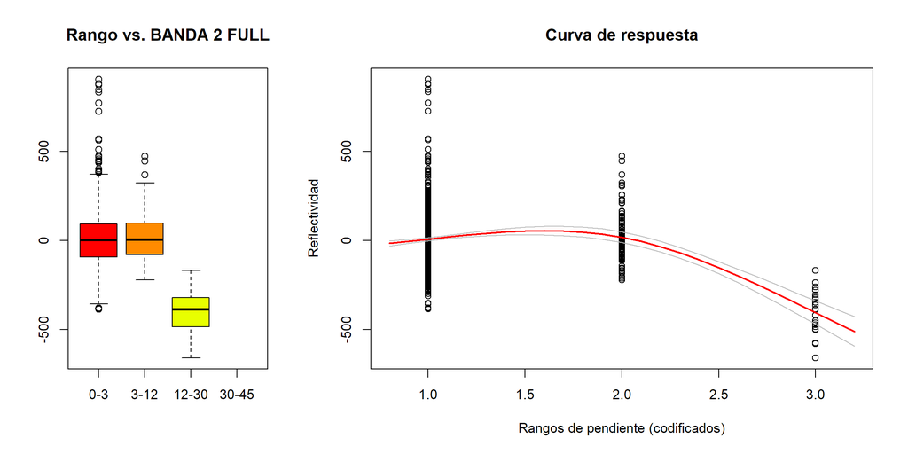

```r
# realizar una visualización del modelo inferido en intervalo de interés
sequence <- data.frame(rango_n=seq(from=0.8, to=3.2, by=0.1))
my_response_b2n <- predict(myfit_b2n, newdata=sequence, type="response", se.fit=TRUE)

# establecer zona de graficas combinadas
layout(matrix(c(1,1,2,2,2,2),1,6,byrow = TRUE))
par(cex = 1.1)

# visualizar relación entre rango de peniente y banda
boxplot(mydataFULL[,"b2n"] ~ factor(mydataFULL[,"rango"], levels= c("0-3","3-12","12-30","30-45")),main="Rango vs. BANDA 2 FULL",col=rainbow(11))

# visualizar la función de respuesta a rango
plot(mydataFULL[,"b2n"] ~ mydataFULL[,"rango_n"], xlim = c(0.8,3.2),
     main = "Curva de respuesta", xlab = "Rangos de pendiente (codificados)", ylab = "Reflectividad")
lines(sequence$rango_n , my_response_b2n$fit, lwd = 2 , col = "red")
lines(sequence$rango_n , my_response_b2n$fit + 1.96*my_response_b2n$se.fit, lwd = 1 , col = "gray")
lines(sequence$rango_n , my_response_b2n$fit - 1.96*my_response_b2n$se.fit, lwd = 1 , col = "gray")
```

### Realizar una corección de valores de reflectividad sustrayendo el efecto esperado de pendiente

```r
# estimar valor de reflectividad esperado con el pendiente
b2n_prediccion <- predict(myfit_b2n, newdata=mydataFULL, type="response", se.fit=TRUE)

# guardar los valores corregidos con el modelo de respuesta a pendiente en la columna "b2n_c1"
mydataFULL[,"b2n_c1"] <- mydataFULL[,"b2n"] - b2n_prediccion$fit
```

### Comparar los datos de reflectividad antes y despues de corección con el modelo *myfit_b2n*

```r
# comparar la columna de reflectividad sin corrección y con corrección
summary(mydataFULL[,c("b2n","b2n_c1")])
```

```
##       b2n                b2n_c1
##  Min.   :-659.7250   Min.   :-392.698
##  1st Qu.: -98.0012   1st Qu.: -98.705
##  Median :   0.0000   Median :  -6.473
##  Mean   :   0.8101   Mean   :   0.000
##  3rd Qu.:  89.4550   3rd Qu.:  85.632
##  Max.   : 904.3100   Max.   : 897.582
```

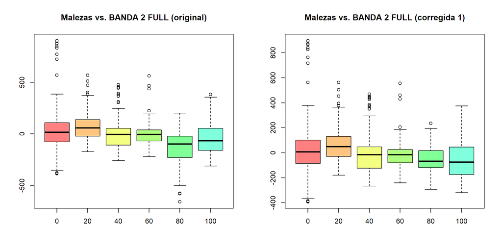

```r
# visualizar respuesta a presencia de maleza sin corección y con corección
par(mfcol = c(1, 2), cex =1)
boxplot(mydataFULL[,"b2n"] ~ factor(mydataFULL[,"porc_veg"], levels= c("0","20","40","60","80","100")),main="Malezas vs. BANDA 2 FULL (original)",col=rainbow(11,s = 0.5))
boxplot(mydataFULL[,"b2n_c1"] ~ factor(mydataFULL[,"porc_veg"], levels= c("0","20","40","60","80","100")),main="Malezas vs. BANDA 2 FULL (corregida 1)",col=rainbow(11,s = 0.5))
```

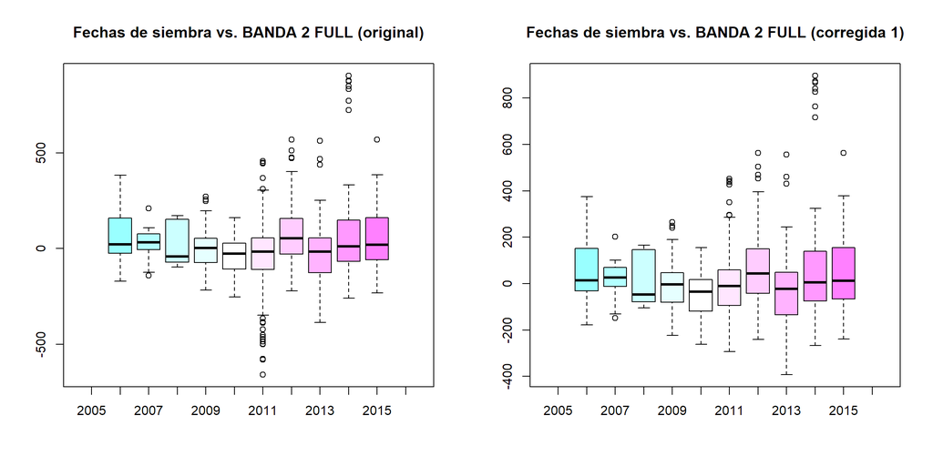

```r
# visualizar respuesta a fecha de siembra de agave sin corección y con corección
par(mfcol = c(1, 2), cex =1)
boxplot(mydataFULL[,"b2n"] ~ factor(mydataFULL[,"fech_siem"], levels= c(seq(from=2005,to=2016,by=1))),main="Fechas de siembra vs. BANDA 2 FULL (original)",col=cm.colors(11))
boxplot(mydataFULL[,"b2n_c1"] ~ factor(mydataFULL[,"fech_siem"], levels= c(seq(from=2005,to=2016,by=1))),main="Fechas de siembra vs. BANDA 2 FULL (corregida 1)",col=cm.colors(11))
```

## segunda corección

### Inferirencia de la respuesta a presencia de maleza para BANDA 2 (modelo *myfit2_b2n*)

```r
# construir un modelo de respuesta de reflectividad a presencia de maleza por medio de GAM
myfit2_b2n <- gam(b2n_c1 ~ s(porc_veg, k=3, fx = TRUE, bs="cr"), data=mydataFULL)

# resumen del modelo inferido
summary(myfit2_b2n)
```

```
##
## Family: gaussian
## Link function: identity
##
## Formula:
## b2n_c1 ~ s(porc_veg, k = 3, fx = TRUE, bs = "cr")
##
## Parametric coefficients:
##              Estimate Std. Error t value Pr(>|t|)
## (Intercept) 1.464e-14  4.208e+00       0        1
##
## Approximate significance of smooth terms:
##             edf Ref.df     F  p-value
## s(porc_veg)   2      2 27.18 2.77e-12 ***
## ---
## Signif. codes:  0 '***' 0.001 '**' 0.01 '*' 0.05 '.' 0.1 ' ' 1
##
## R-sq.(adj) =  0.0396   Deviance explained = 4.11%
## GCV =  22582  Scale est. = 22529     n = 1272
```

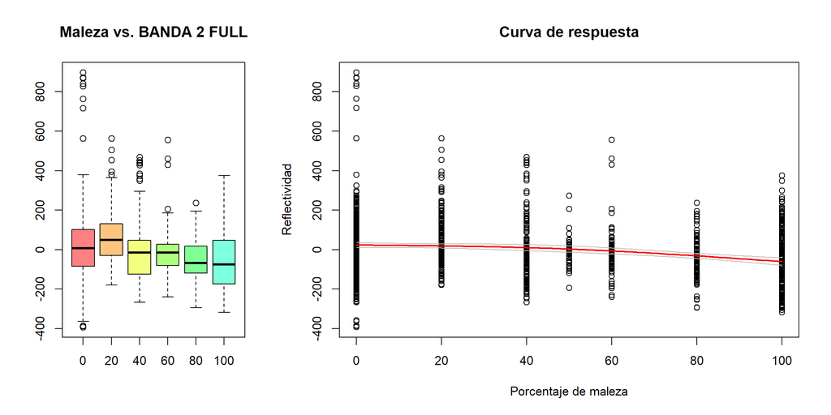

```r
# realizar una visualización del modelo inferido en intervalo de interés
sequence2 <- data.frame(porc_veg=seq(from=0, to=100, by=1))
my_response2_b2n <- predict(myfit2_b2n, newdata=sequence2, type="response", se.fit=TRUE)

# establecer zona de graficas combinadas
layout(matrix(c(1,1,2,2,2,2),1,6,byrow = TRUE))
par(cex = 1.1)

# visualizar relación entre maleza y banda
boxplot(mydataFULL[,"b2n_c1"] ~ factor(mydataFULL[,"porc_veg"], levels= c("0","20","40","60","80","100")),main="Maleza vs. BANDA 2 FULL",col=rainbow(11, s = 0.5))

# visualizar la función de respuesta a presencia de maleza
plot(mydataFULL[,"b2n_c1"] ~ mydataFULL[,"porc_veg"], xlim = c(0,100),
     main = "Curva de respuesta", xlab = "Porcentaje de maleza", ylab = "Reflectividad")
lines(sequence2$porc_veg , my_response2_b2n$fit, lwd = 2 , col = "red")
lines(sequence2$porc_veg , my_response2_b2n$fit + 1.96*my_response2_b2n$se.fit, lwd = 1 , col = "gray")
lines(sequence2$porc_veg , my_response2_b2n$fit - 1.96*my_response2_b2n$se.fit, lwd = 1 , col = "gray")
```

### Realizar segunda corección de valores de reflectividad sustrayendo el efecto esperado de porcentaje de malezas

```r
# estimar valor de reflectividad esperado con el pendiente
b2n_prediccion2 <- predict(myfit2_b2n, newdata=mydataFULL, type="response", se.fit=TRUE)

# guardar los valores corregidos con el modelo de respuesta a pendiente en la columna "b2n_c2"
mydataFULL[,"b2n_c2"] <- mydataFULL[,"b2n_c1"] - b2n_prediccion2$fit
```

### Comparar los datos de reflectividad antes y despues de corección con el modelo *myfit2_b2n*

```r
# comparar la columna de reflectividad sin corrección y con corrección
summary(mydataFULL[,c("b2n","b2n_c2")])
```

```
##       b2n                b2n_c2
##  Min.   :-659.7250   Min.   :-415.72
##  1st Qu.: -98.0012   1st Qu.: -90.99
##  Median :   0.0000   Median : -14.02
##  Mean   :   0.8101   Mean   :   0.00
##  3rd Qu.:  89.4550   3rd Qu.:  75.62
##  Max.   : 904.3100   Max.   : 874.56
```

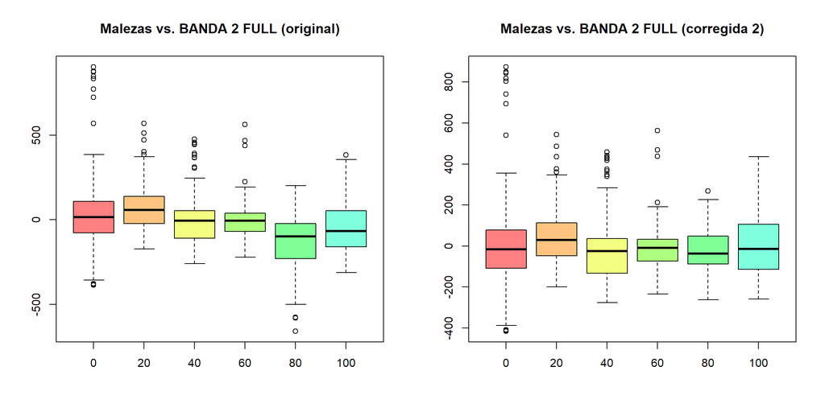

```r
# visualizar respuesta a presencia de maleza sin corección y con corección
par(mfcol = c(1, 2), cex =1)
boxplot(mydataFULL[,"b2n"] ~ factor(mydataFULL[,"porc_veg"], levels= c("0","20","40","60","80","100")),main="Malezas vs. BANDA 2 FULL (original)",col=rainbow(11,s = 0.5))
boxplot(mydataFULL[,"b2n_c2"] ~ factor(mydataFULL[,"porc_veg"], levels= c("0","20","40","60","80","100")),main="Malezas vs. BANDA 2 FULL (corregida 2)",col=rainbow(11,s = 0.5))
```

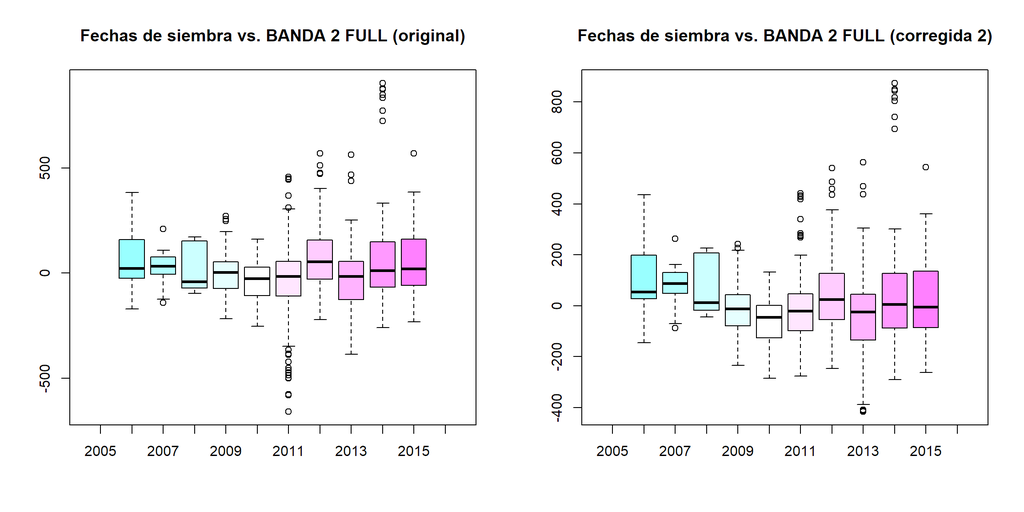

```r
# visualizar respuesta a fecha de siembra de agave sin corección y con corección
par(mfcol = c(1, 2), cex =1)
boxplot(mydataFULL[,"b2n"] ~ factor(mydataFULL[,"fech_siem"], levels= c(seq(from=2005,to=2016,by=1))),main="Fechas de siembra vs. BANDA 2 FULL (original)",col=cm.colors(11))
boxplot(mydataFULL[,"b2n_c2"] ~ factor(mydataFULL[,"fech_siem"], levels= c(seq(from=2005,to=2016,by=1))),main="Fechas de siembra vs. BANDA 2 FULL (corregida 2)",col=cm.colors(11))
```